# Homework 2

## Introduction

In this assignment, it is tried to predict "Unleaded Gasoline Sale" with the given data. To accomplish that, the most meaningful model that is achieved will be used. After the finding the best model, the analysis of the validation of the model will be conducted.

The variables that are used in this study and their summaries as follows:

UGS: Unleaded gasoline sale in a given quarter,  
RNUV: An index indicating the rate of new unleaded gasoline using vehicles being added to the traffic in a quarter,  
PU: Average price (adjusted with an index) of a liter of unleaded gasoline in a quarter,  
PG: Average price (adjusted with an index) of a liter of diesel gasoline in a quarter,  
NUGV: Number of unleaded gasoline using vehicles in the traffic,  
NDGV: Number of diesel gasoline using vehicles in the traffic (per 1000 people),  
GNPA: Agriculture component of Gross National Product (adjusted with an index),  
GNPC: Commerce component of Gross National Product (adjusted with an index),  
GNP: Grand total for GNP (agriculture, commerce and other components total).

## Required Libraries

```r
library(readxl)
library(ggplot2)
library(dplyr)
library(tidyr)
library(lubridate)
library(RColorBrewer)
library(zoo)
library(ggcorrplot)
library(forecast)
library(fpp)
```

## Read the Data

```r
setwd("C:/Users/SaidBahçeci/Desktop")
data = read.csv("IE360_Spring22_HW2_data.csv")
data$Quarter = as.yearqtr(data$Quarter, format = "%Y_Q%q")
```

## Plot of the Time Series of UGS

[output not shown]

|  | Qtr1 | Qtr2 | Qtr3 | Qtr4 |
| --- | --- | --- | --- | --- |
| 2000 | 1128971 | 1199569 | 1370167 | 1127548 |
| 2001 | 1033918 | 1019754 | 1209916 | 1002789 |
| 2002 | 893722 | 1027252 | 1153265 | 991981 |
| 2003 | 806257 | 960556 | 1104825 | 934022 |
| 2004 | 832350 | 975165 | 1094823 | 854517 |
| 2005 | 762559 | 890693 | 1040946 | 793399 |
| 2006 | 736580 | 877614 | 946783 | 872000 |

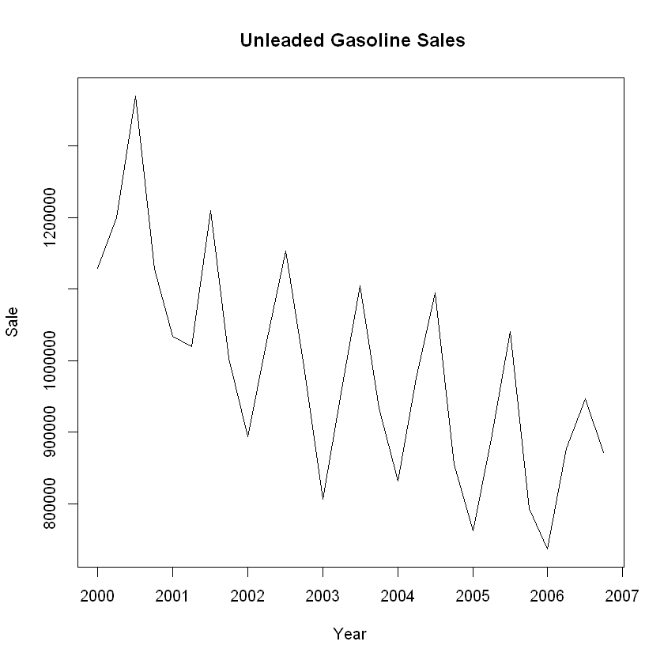

```r
tsdata = ts(data$Unleaded.Gasoline.Sale..UGS.[1:28],freq=4,start=c(2000,1))
tsdata
ts.plot(tsdata,xlab = "Year", ylab = "Sale",main=" Unleaded Gasoline Sales")
```

It can be observed that there is an downward tren through years and clear seasonality. And, it is not stationary at all, since the means of different parts of the data do not yield the same value.

## Plot of the Autocorrelation Functions

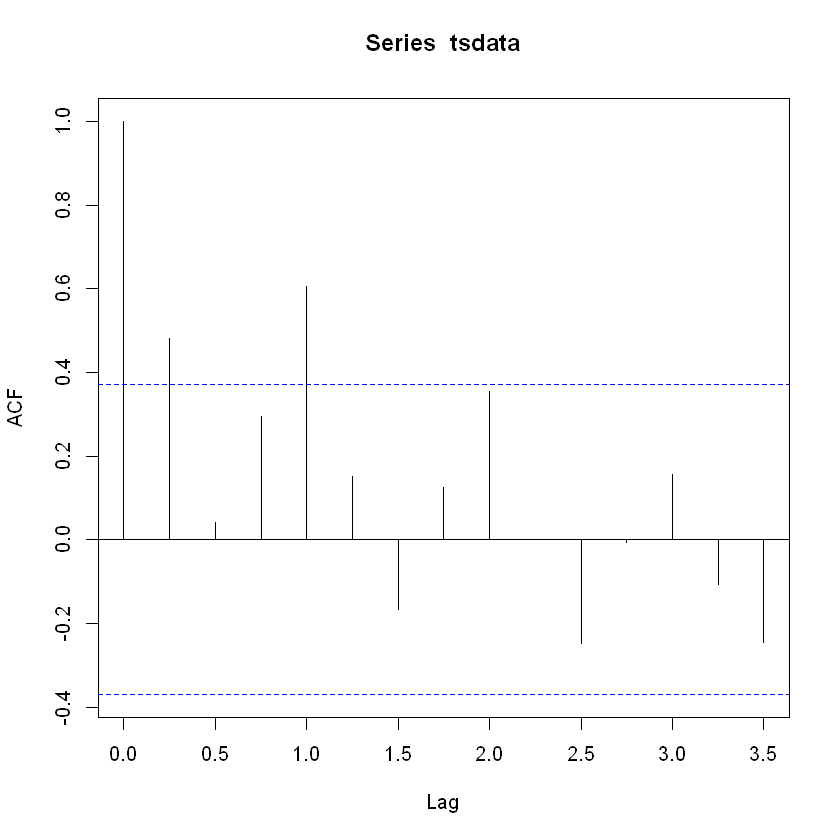

```r
acf(tsdata)
```

There is an relativeley high and decreasing lag in 0.0, 1.0, 2.0, 3.0. It might be originated from the seasonality. On the other hand, since there is a pattern and some lags are higher than allowed limit, the autocorrelation is an issue.

## Build of the Initial Model

```r
data$trend = (1:32)
data$seasonality = rep(1:4,8)
data$seasonality = as.factor(data$seasonality)
data$lagged = c(NA)
for(i in 1:28){
    data$lagged[i+1] = data$Unleaded.Gasoline.Sale..UGS.[i]
}
```

Trend added. Seasonality added with quarter factor. Lagged values added.

```r
fit1 = lm(Unleaded.Gasoline.Sale..UGS. ~.-Quarter,  data = data[1:28,])
summary(fit1)
```

```
Call:
lm(formula = Unleaded.Gasoline.Sale..UGS. ~ . - Quarter, data = data[1:28,
    ])

Residuals:
   Min     1Q Median     3Q    Max
-38230  -9740   2424   7841  34696

Coefficients:
                                        Estimate Std. Error t value Pr(>|t|)
(Intercept)                            4.244e+06  1.187e+06   3.575  0.00382 **
RNUV                                   3.575e+06  1.989e+06   1.797  0.09752 .
X..LPG.Vehicles..NLPG.                -5.052e-01  2.295e-01  -2.201  0.04803 *
Price.of.Unleaded.Gasoline..PU.        1.008e+03  1.169e+03   0.862  0.40548
Price.of.Diesel.Gasoline..PG.         -2.872e+03  1.805e+03  -1.591  0.13762
X..Unleaded.Gasoline.Vehicles..NUGV.  -1.199e+00  4.743e-01  -2.529  0.02649 *
X..of.Diesel.Gasoline.Vehicles..NDGV.  1.379e+04  4.895e+03   2.817  0.01554 *
GNP.Agriculture                       -3.553e-02  3.991e-02  -0.890  0.39083
GNP.Commerce                           1.475e-01  6.619e-02   2.228  0.04575 *
GNP.Total                             -1.350e-02  1.314e-02  -1.027  0.32458
trend                                  1.629e+04  1.803e+04   0.903  0.38408
seasonality2                          -1.458e+04  6.458e+04  -0.226  0.82522
seasonality3                           2.940e+05  1.952e+05   1.506  0.15800
seasonality4                           1.429e+05  7.572e+04   1.887  0.08362 .
lagged                                -5.841e-01  2.375e-01  -2.459  0.03007 *
---
Signif. codes:  0 '***' 0.001 '**' 0.01 '*' 0.05 '.' 0.1 ' ' 1

Residual standard error: 25860 on 12 degrees of freedom
  (1 observation deleted due to missingness)
Multiple R-squared:  0.9865,	Adjusted R-squared:  0.9708
F-statistic: 62.71 on 14 and 12 DF,  p-value: 5.179e-09
```

For the first model, in addition to all variables, seasonality, trend and lagged values are used. To make a meaningful model, backward selection will be used. The insignificant variables will be eliminated with considering the meaning and autocorrelations between the variables.

## Autocorrelation Plot

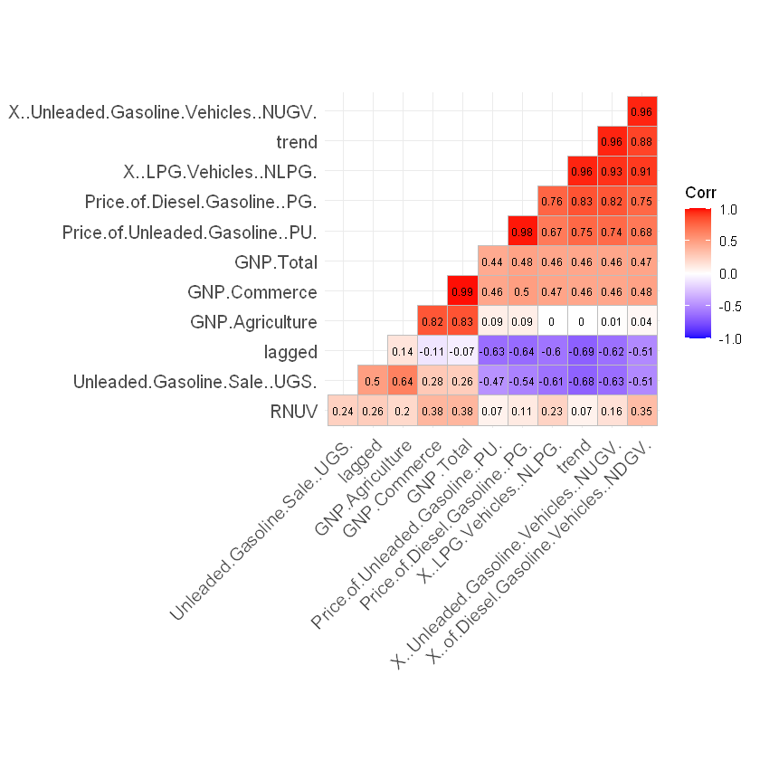

```r
wo_na_data = data[!is.na(data$Unleaded.Gasoline.Sale..UGS. & data$lagged),]
corr = cor(wo_na_data[,unlist(lapply(wo_na_data, is.numeric))])
ggcorrplot(corr,
           hc.order = TRUE,
           type='lower',
           lab=TRUE,
           lab_size = 2.5)
```

## Build of Alternative Models

```r
fit2 <- lm(Unleaded.Gasoline.Sale..UGS. ~. - Quarter - GNP.Agriculture, data = data[1:28,])
summary(fit2)
```

```
Call:
lm(formula = Unleaded.Gasoline.Sale..UGS. ~ . - Quarter - GNP.Agriculture,
    data = data[1:28, ])

Residuals:
   Min     1Q Median     3Q    Max
-36276 -10557   1677   8345  34886

Coefficients:
                                        Estimate Std. Error t value Pr(>|t|)
(Intercept)                            4.144e+06  1.172e+06   3.535  0.00366 **
RNUV                                   2.934e+06  1.839e+06   1.595  0.13477
X..LPG.Vehicles..NLPG.                -4.081e-01  2.003e-01  -2.037  0.06251 .
Price.of.Unleaded.Gasoline..PU.        5.274e+02  1.028e+03   0.513  0.61665
Price.of.Diesel.Gasoline..PG.         -1.959e+03  1.474e+03  -1.329  0.20663
X..Unleaded.Gasoline.Vehicles..NUGV.  -1.149e+00  4.672e-01  -2.460  0.02867 *
X..of.Diesel.Gasoline.Vehicles..NDGV.  1.336e+04  4.832e+03   2.764  0.01610 *
GNP.Commerce                           1.311e-01  6.308e-02   2.079  0.05799 .
GNP.Total                             -1.730e-02  1.233e-02  -1.403  0.18419
trend                                  1.084e+04  1.682e+04   0.644  0.53058
seasonality2                          -1.141e+04  6.396e+04  -0.178  0.86114
seasonality3                           1.793e+05  1.455e+05   1.232  0.23977
seasonality4                           1.555e+05  7.378e+04   2.108  0.05503 .
lagged                                -6.615e-01  2.192e-01  -3.017  0.00990 **
---
Signif. codes:  0 '***' 0.001 '**' 0.01 '*' 0.05 '.' 0.1 ' ' 1

Residual standard error: 25650 on 13 degrees of freedom
  (1 observation deleted due to missingness)
Multiple R-squared:  0.9856,	Adjusted R-squared:  0.9713
F-statistic: 68.57 on 13 and 13 DF,  p-value: 8.776e-10
```

```r
fit3 <- lm(Unleaded.Gasoline.Sale..UGS. ~. - Quarter - GNP.Agriculture - Price.of.Diesel.Gasoline..PG. , data = data[1:28,])
summary(fit3)
```

```
Call:
lm(formula = Unleaded.Gasoline.Sale..UGS. ~ . - Quarter - GNP.Agriculture -
    Price.of.Diesel.Gasoline..PG., data = data[1:28, ])

Residuals:
   Min     1Q Median     3Q    Max
-40943  -8129    632   8792  37681

Coefficients:
                                        Estimate Std. Error t value Pr(>|t|)
(Intercept)                            3.618e+06  1.133e+06   3.193 0.006517
RNUV                                   2.121e+06  1.782e+06   1.191 0.253641
X..LPG.Vehicles..NLPG.                -2.461e-01  1.633e-01  -1.507 0.153966
Price.of.Unleaded.Gasoline..PU.       -8.195e+02  1.803e+02  -4.544 0.000459
X..Unleaded.Gasoline.Vehicles..NUGV.  -9.573e-01  4.563e-01  -2.098 0.054549
X..of.Diesel.Gasoline.Vehicles..NDGV.  1.154e+04  4.759e+03   2.424 0.029482
GNP.Commerce                           8.812e-02  5.561e-02   1.585 0.135369
GNP.Total                             -1.341e-02  1.231e-02  -1.090 0.294227
trend                                  8.754e+02  1.546e+04   0.057 0.955659
seasonality2                           2.986e+04  5.743e+04   0.520 0.611222
seasonality3                           2.436e+05  1.409e+05   1.728 0.105961
seasonality4                           1.826e+05  7.283e+04   2.507 0.025129
lagged                                -6.302e-01  2.238e-01  -2.815 0.013763

(Intercept)                           **
RNUV
X..LPG.Vehicles..NLPG.
Price.of.Unleaded.Gasoline..PU.       ***
X..Unleaded.Gasoline.Vehicles..NUGV.  .
X..of.Diesel.Gasoline.Vehicles..NDGV. *
GNP.Commerce
GNP.Total
trend
seasonality2
seasonality3
seasonality4                          *
lagged                                *
---
Signif. codes:  0 '***' 0.001 '**' 0.01 '*' 0.05 '.' 0.1 ' ' 1

Residual standard error: 26350 on 14 degrees of freedom
  (1 observation deleted due to missingness)
Multiple R-squared:  0.9837,	Adjusted R-squared:  0.9697
F-statistic: 70.29 on 12 and 14 DF,  p-value: 2.28e-10
```

The less Adjusted R-squared value is observed, but since a meaningful elimination is performed, it will be continued.

The next variable eliminated will be "GNP.Total".

```r
fit4 <- lm(Unleaded.Gasoline.Sale..UGS. ~. - Quarter - Price.of.Diesel.Gasoline..PG. - GNP.Agriculture - GNP.Total, data = data[1:28,])
summary(fit4)
```

```
Call:
lm(formula = Unleaded.Gasoline.Sale..UGS. ~ . - Quarter - Price.of.Diesel.Gasoline..PG. -
    GNP.Agriculture - GNP.Total, data = data[1:28, ])

Residuals:
   Min     1Q Median     3Q    Max
-40209 -12943  -1301  11427  42071

Coefficients:
                                        Estimate Std. Error t value Pr(>|t|)
(Intercept)                            2.863e+06  9.023e+05   3.173 0.006307
RNUV                                   1.512e+06  1.703e+06   0.888 0.388393
X..LPG.Vehicles..NLPG.                -1.471e-01  1.365e-01  -1.078 0.298274
Price.of.Unleaded.Gasoline..PU.       -7.901e+02  1.794e+02  -4.403 0.000513
X..Unleaded.Gasoline.Vehicles..NUGV.  -6.971e-01  3.913e-01  -1.782 0.095079
X..of.Diesel.Gasoline.Vehicles..NDGV.  9.130e+03  4.242e+03   2.152 0.048079
GNP.Commerce                           6.260e-02  5.075e-02   1.233 0.236383
trend                                 -9.762e+03  1.207e+04  -0.809 0.431247
seasonality2                           1.707e+04  5.657e+04   0.302 0.766926
seasonality3                           1.597e+05  1.188e+05   1.344 0.198914
seasonality4                           1.412e+05  6.256e+04   2.258 0.039302
lagged                                -6.607e-01  2.235e-01  -2.956 0.009804

(Intercept)                           **
RNUV
X..LPG.Vehicles..NLPG.
Price.of.Unleaded.Gasoline..PU.       ***
X..Unleaded.Gasoline.Vehicles..NUGV.  .
X..of.Diesel.Gasoline.Vehicles..NDGV. *
GNP.Commerce
trend
seasonality2
seasonality3
seasonality4                          *
lagged                                **
---
Signif. codes:  0 '***' 0.001 '**' 0.01 '*' 0.05 '.' 0.1 ' ' 1

Residual standard error: 26510 on 15 degrees of freedom
  (1 observation deleted due to missingness)
Multiple R-squared:  0.9823,	Adjusted R-squared:  0.9693
F-statistic: 75.62 on 11 and 15 DF,  p-value: 4.422e-11
```

```r
fit5 <- lm(Unleaded.Gasoline.Sale..UGS. ~. - Quarter - Price.of.Diesel.Gasoline..PG. - GNP.Agriculture - GNP.Total - RNUV, data = data[1:28,])
summary(fit5)
```

```
Call:
lm(formula = Unleaded.Gasoline.Sale..UGS. ~ . - Quarter - Price.of.Diesel.Gasoline..PG. -
    GNP.Agriculture - GNP.Total - RNUV, data = data[1:28, ])

Residuals:
   Min     1Q Median     3Q    Max
-44248 -10032  -4735  13501  47612

Coefficients:
                                        Estimate Std. Error t value Pr(>|t|)
(Intercept)                            3.065e+06  8.673e+05   3.534 0.002759
X..LPG.Vehicles..NLPG.                -1.588e-01  1.350e-01  -1.176 0.256657
Price.of.Unleaded.Gasoline..PU.       -7.559e+02  1.741e+02  -4.342 0.000504
X..Unleaded.Gasoline.Vehicles..NUGV.  -8.582e-01  3.444e-01  -2.492 0.024074
X..of.Diesel.Gasoline.Vehicles..NDGV.  1.107e+04  3.610e+03   3.067 0.007367
GNP.Commerce                           5.354e-02  4.939e-02   1.084 0.294407
trend                                 -6.314e+03  1.135e+04  -0.556 0.585778
seasonality2                           3.202e+04  5.365e+04   0.597 0.558918
seasonality3                           1.842e+05  1.148e+05   1.604 0.128252
seasonality4                           1.539e+05  6.051e+04   2.543 0.021694
lagged                                -6.112e-01  2.150e-01  -2.843 0.011750

(Intercept)                           **
X..LPG.Vehicles..NLPG.
Price.of.Unleaded.Gasoline..PU.       ***
X..Unleaded.Gasoline.Vehicles..NUGV.  *
X..of.Diesel.Gasoline.Vehicles..NDGV. **
GNP.Commerce
trend
seasonality2
seasonality3
seasonality4                          *
lagged                                *
---
Signif. codes:  0 '***' 0.001 '**' 0.01 '*' 0.05 '.' 0.1 ' ' 1

Residual standard error: 26330 on 16 degrees of freedom
  (1 observation deleted due to missingness)
Multiple R-squared:  0.9814,	Adjusted R-squared:  0.9697
F-statistic: 84.22 on 10 and 16 DF,  p-value: 6.76e-12
```

```r
fit6 <- lm(Unleaded.Gasoline.Sale..UGS. ~. - Quarter - Price.of.Diesel.Gasoline..PG. - GNP.Agriculture - GNP.Total - RNUV - GNP.Commerce, data = data[1:28,])
summary(fit6)
```

```
Call:
lm(formula = Unleaded.Gasoline.Sale..UGS. ~ . - Quarter - Price.of.Diesel.Gasoline..PG. -
    GNP.Agriculture - GNP.Total - RNUV - GNP.Commerce, data = data[1:28,
    ])

Residuals:
   Min     1Q Median     3Q    Max
-48317 -13744  -1183  15259  37654

Coefficients:
                                        Estimate Std. Error t value Pr(>|t|)
(Intercept)                            3.487e+06  7.791e+05   4.476 0.000333
X..LPG.Vehicles..NLPG.                -1.824e-01  1.339e-01  -1.362 0.190939
Price.of.Unleaded.Gasoline..PU.       -6.976e+02  1.664e+02  -4.192 0.000612
X..Unleaded.Gasoline.Vehicles..NUGV.  -1.054e+00  2.947e-01  -3.577 0.002320
X..of.Diesel.Gasoline.Vehicles..NDGV.  1.304e+04  3.140e+03   4.152 0.000667
trend                                  1.945e+03  8.460e+03   0.230 0.820941
seasonality2                           8.435e+04  2.354e+04   3.583 0.002292
seasonality3                           3.073e+05  1.700e+04  18.072 1.56e-12
seasonality4                           2.034e+05  3.992e+04   5.096 8.98e-05
lagged                                -5.013e-01  1.905e-01  -2.631 0.017523

(Intercept)                           ***
X..LPG.Vehicles..NLPG.
Price.of.Unleaded.Gasoline..PU.       ***
X..Unleaded.Gasoline.Vehicles..NUGV.  **
X..of.Diesel.Gasoline.Vehicles..NDGV. ***
trend
seasonality2                          **
seasonality3                          ***
seasonality4                          ***
lagged                                *
---
Signif. codes:  0 '***' 0.001 '**' 0.01 '*' 0.05 '.' 0.1 ' ' 1

Residual standard error: 26470 on 17 degrees of freedom
  (1 observation deleted due to missingness)
Multiple R-squared:   0.98,	Adjusted R-squared:  0.9694
F-statistic: 92.49 on 9 and 17 DF,  p-value: 1.18e-12
```

The next variable eliminated will be "X..LPG.Vehicles..NLPG." whic is the only insignificant variable except "trend".

```r
fit7 <- lm(Unleaded.Gasoline.Sale..UGS. ~. - Quarter - Price.of.Diesel.Gasoline..PG. - GNP.Agriculture - GNP.Total - RNUV - GNP.Commerce - X..LPG.Vehicles..NLPG., data = data[1:28,])
summary(fit7)
```

```
Call:
lm(formula = Unleaded.Gasoline.Sale..UGS. ~ . - Quarter - Price.of.Diesel.Gasoline..PG. -
    GNP.Agriculture - GNP.Total - RNUV - GNP.Commerce - X..LPG.Vehicles..NLPG.,
    data = data[1:28, ])

Residuals:
   Min     1Q Median     3Q    Max
-44528 -10996  -4285  15377  39939

Coefficients:
                                        Estimate Std. Error t value Pr(>|t|)
(Intercept)                            2.796e+06  6.050e+05   4.621 0.000212
Price.of.Unleaded.Gasoline..PU.       -6.308e+02  1.628e+02  -3.876 0.001108
X..Unleaded.Gasoline.Vehicles..NUGV.  -7.551e-01  2.011e-01  -3.755 0.001450
X..of.Diesel.Gasoline.Vehicles..NDGV.  9.724e+03  2.033e+03   4.782 0.000149
trend                                 -8.559e+03  3.562e+03  -2.403 0.027253
seasonality2                           9.041e+04  2.366e+04   3.821 0.001252
seasonality3                           3.099e+05  1.729e+04  17.924 6.33e-13
seasonality4                           1.985e+05  4.069e+04   4.878 0.000121
lagged                                -4.865e-01  1.947e-01  -2.499 0.022362

(Intercept)                           ***
Price.of.Unleaded.Gasoline..PU.       **
X..Unleaded.Gasoline.Vehicles..NUGV.  **
X..of.Diesel.Gasoline.Vehicles..NDGV. ***
trend                                 *
seasonality2                          **
seasonality3                          ***
seasonality4                          ***
lagged                                *
---
Signif. codes:  0 '***' 0.001 '**' 0.01 '*' 0.05 '.' 0.1 ' ' 1

Residual standard error: 27090 on 18 degrees of freedom
  (1 observation deleted due to missingness)
Multiple R-squared:  0.9778,	Adjusted R-squared:  0.9679
F-statistic: 99.11 on 8 and 18 DF,  p-value: 2.71e-13
```

All variables are somehow significant. The backward selection method brings us to this model. Now, we can predict the "Unleaded.Gasoline.Sale..UGS." variable with the "fit7" model.

## Validity of the Model

```
	Breusch-Godfrey test for serial correlation of order up to 12

data:  Residuals
LM test = 20.476, df = 12, p-value = 0.05859
```

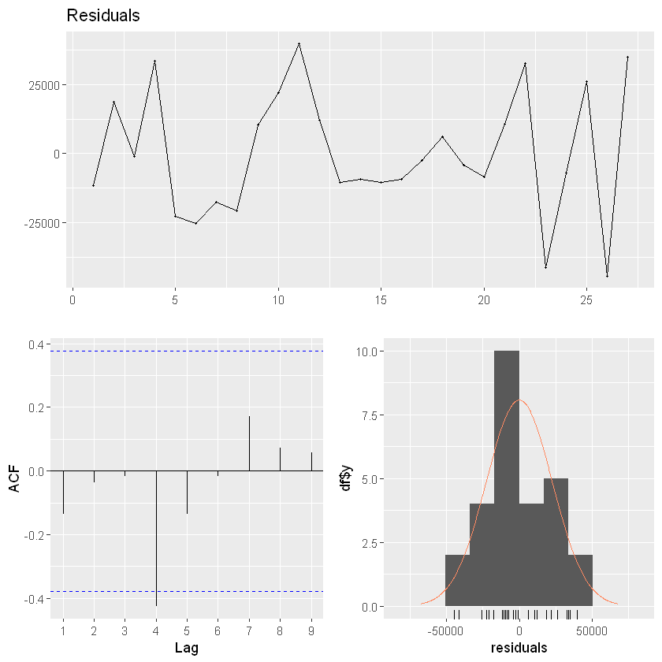

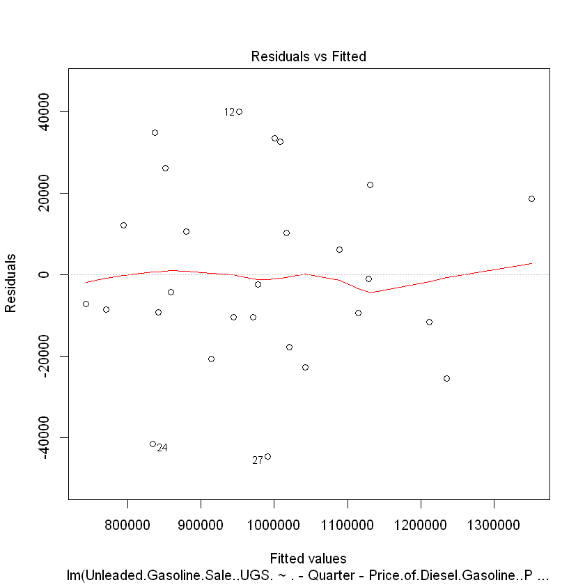

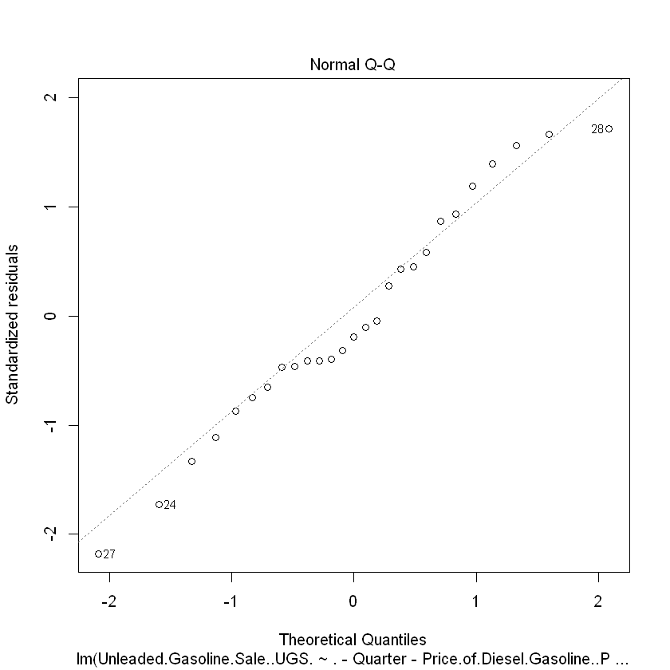

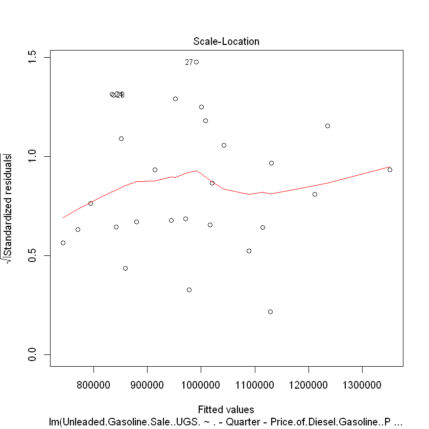

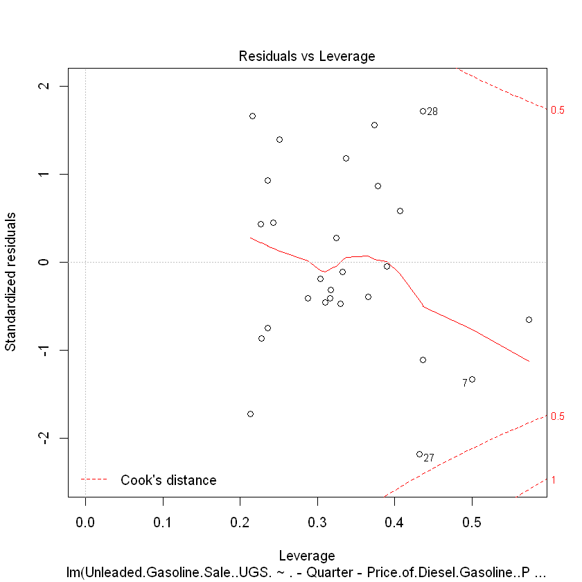

```r
checkresiduals(fit7)
plot(fit7)
```

Despite the 4th lag slightly exceeds the limit, they look like white noises. And residuals might be considered as they are fitted on normal distribution and it can be said that there is a sufficient randomness to say that they are not autocorrelated. These sufficiency is originated from the not enough data to develop a good model.

## Forecasting for the Year 2007

```r
predictions = c()
for(i in 1:4){
  predictions[i] = predict(fit7,newdata=data[i+28,])
  if(i+28 < 32){
    data$lagged[i+29] = predictions[i]
  }
}
predictions
```

1. 662492.280517707

2. 845565.070512685

3. 965974.609010775

4. 788131.257443193

Forecast of the quarters of 2007 are as follows:

##### 1st Quarter: 662492

##### 2nd Quarter: 845565

##### 3rd Quarter: 965975

##### 4th Quarter: 788131

Since, the actual data of these quarters are not given, a comparison with actual with is not possible.

## Conclusion

To sum up, it is tried to predict best values for "Unleaded Gasoline Sale" for year 2007. The model that made this prediction is build with the backwards selection. While making the eliminations, the autocorrelations, p values, their meanings and significancy are considered. On the other hand, the model is not perfect because of the lack of sufficient data.